# Rerun-outlier-removal

# **Summary**

We were interested in whether the sexual dimorphism found in many livebearing species played a role in thermal tolerance. We tested for sex-biased tolerance in CTmax and CTmin trials in three livebearing species: sailfin mollies (*P. latipinna*), Western mosquitofish (*G. affinis*), and Panuco swordtail (*X. nigrensis*). We also tested whether male morphs (i.e. large and small males) within one species (swordtail) affected thermal tolerance.

Likewise, male morphs did *not* influence thermal tolerance, further confirming that this is likely no detectable sex-biased thermal differences in our current setup.

# **Tables/Figures**

## Tables

### Model coefficients

```r
cr2.table <- function(model, trait, label) {
  V <- vcovCR(model, type = "CR2")

  as.data.frame(
    conf_int(model, vcov = V, level = 0.95, test = "Satterthwaite", p_values = TRUE)) %>%
    filter(Coef %in% c("Sexmale", "Size.mm")) %>%
    transmute(
      Trait = trait,
      Model = label,
      Predictor = Coef,
      CR2_Estimate = beta,
      CR2_SE = SE,
      CR2_low = CI_L,
      CR2_high = CI_U,
      CR2_p = p_val)
}

O.cr2.results <- bind_rows(
  cr2.table(mod2b, "CTmin", "B"),
  cr2.table(mod2c, "CTmin", "C"),
  cr2.table(mod2d, "CTmin", "D"),
  cr2.table(mod2e, "CTmin", "E"),
  cr2.table(mod1b, "CTmax", "B"),
  cr2.table(mod1c, "CTmax", "C"),
  cr2.table(mod1d, "CTmax", "D"),
  cr2.table(mod1e, "CTmax", "E"))

O.model.results <- bind_rows(
  ctmin.results %>% mutate(Trait = "CTmin"),
  ctmax.results %>% mutate(Trait = "CTmax")) %>%
  transmute(
    Trait,
    Model,
    Predictor,
    MB_Estimate = Estimate,
    MB_SE = `Std. Error`,
    MB_low = CI_low,
    MB_high = CI_high,
    MB_df = df,
    MB_p = `Pr(>|t|)`)

O.combined.results <- O.model.results %>%
  left_join(O.cr2.results, by = c("Trait", "Model", "Predictor")) %>%
  mutate(
    Trait = factor(Trait, levels = c("CTmin", "CTmax")),
    Model = factor(Model, levels = c("B", "C", "D", "E")),
    Effect = case_when(
      Predictor == "Sexmale" ~ "Sex",
      Predictor == "Size.mm" ~ "Size",
      TRUE ~ Predictor)) %>%
  arrange(Trait, Model, match(Predictor, c("Sexmale", "Size.mm")))

O.combined.results <- O.combined.results %>%
  mutate(
    p.disp.mb = case_when(
      MB_p < 0.001 ~ "*p* < 0.001",
      MB_p < 0.05  ~ paste0(sprintf("%.3f", MB_p)),
      TRUE            ~ sprintf("%.3f", MB_p))) %>%
  mutate(
    p.disp.cr2 = case_when(
      CR2_p < 0.001 ~ "*p* < 0.001",
      CR2_p < 0.05  ~ paste0(sprintf("%.3f", CR2_p)),
      TRUE            ~ sprintf("%.3f", CR2_p)))

O.table.results <- O.combined.results %>%
  mutate(
    Model = dplyr::recode(
      as.character(Model),
      "B" = "Species + Size",
      "C" = "Species + Sex",
      "D" = "Species + Sex \n+Size",
      "E" = "Species + Sex*Size")) %>%
  transmute(
    Trait,
    Model,
    Effect,
    mb_est = sprintf("%.3f (%.3f)", MB_Estimate, MB_SE),
    mb_ci = sprintf("[%.3f, %.3f]", MB_low, MB_high),
    mb_df = sprintf("%.2f", MB_df),
    mb_p = p.disp.mb,

    cr2_est = sprintf("%.3f (%.3f)", CR2_Estimate, CR2_SE),
    cr2_ci = sprintf("[%.3f, %.3f]", CR2_low, CR2_high),
    cr2_p = p.disp.cr2)

O.coeff.table <- O.table.results %>%
  gt(rowname_col = "Model", groupname_col = "Trait", row_group_as_column = TRUE) %>%
  tab_stubhead(label = "Model") %>%
  tab_spanner(label = "Model-based inference", columns = c(Effect, mb_est, mb_ci, mb_df, mb_p)) %>%
  tab_spanner(label = "CR2 analysis", columns = c(cr2_est, cr2_ci, cr2_p)) %>%
  cols_label(
    Effect = "Effect",
    mb_est = "Estimate (SE)",
    mb_ci = "95% CI",
    mb_df = "df",
    mb_p = md("*p*-value"),
    cr2_est = "Estimate (SE)",
    cr2_ci = "95% CI",
    cr2_p = md("*p*-value")) %>%
  tab_style(
    style = cell_borders(sides = "right", color = "lightgray", weight = px(1.5)),
    locations = cells_body(columns = c(Effect,mb_est, mb_ci,mb_df, cr2_est, cr2_ci))) %>%
  tab_style(
    style = cell_borders(sides = "right", color = "lightgray", weight = px(2)),
    locations = cells_body(columns = c(mb_p))) %>%
  cols_align("center", everything()) %>%
  opt_horizontal_padding(scale = 2)

O.coeff.table
```

| Model | Model | Model-based inference Effect | Model-based inference Estimate (SE) | Model-based inference 95% CI | Model-based inference df | Model-based inference *p*-value | CR2 analysis Estimate (SE) | CR2 analysis 95% CI | CR2 analysis *p*-value |
| --- | --- | --- | --- | --- | --- | --- | --- | --- | --- |
| CTmin | Species + Size | Size | -0.035 (0.016) | [-0.067, -0.004] | 78.19 | 0.029 | -0.035 (0.022) | [-0.088, 0.017] | 0.154 |
|  | Species + Sex | Sex | 0.215 (0.125) | [-0.034, 0.464] | 76.19 | 0.089 | 0.215 (0.105) | [-0.017, 0.448] | 0.066 |
|  | Species + Sex +Size | Sex | 0.198 (0.122) | [-0.045, 0.440] | 76.20 | 0.109 | 0.198 (0.119) | [-0.068, 0.463] | 0.128 |
|  | Species + Sex +Size | Size | -0.034 (0.016) | [-0.065, -0.002] | 78.17 | 0.035 | -0.034 (0.019) | [-0.080, 0.012] | 0.126 |
|  | Species + Sex*Size | Sex | 0.202 (0.681) | [-1.153, 1.558] | 76.68 | 0.767 | 0.202 (0.636) | [-1.349, 1.754] | 0.761 |
|  | Species + Sex*Size | Size | -0.034 (0.021) | [-0.076, 0.009] | 76.48 | 0.119 | -0.034 (0.026) | [-0.098, 0.031] | 0.250 |
|  | Species + Sex*Size | Sexmale:Size.mm | -0.000 (0.023) | [-0.046, 0.046] | 76.69 | 0.995 | NA (NA) | [NA, NA] | NA |
| CTmax | Species + Size | Size | 0.016 (0.016) | [-0.016, 0.048] | 88.00 | 0.315 | 0.016 (0.021) | [-0.034, 0.066] | 0.468 |
|  | Species + Sex | Sex | -0.208 (0.143) | [-0.491, 0.076] | 88.00 | 0.149 | -0.208 (0.187) | [-0.622, 0.207] | 0.292 |
|  | Species + Sex +Size | Sex | -0.201 (0.142) | [-0.483, 0.082] | 88.00 | 0.161 | -0.201 (0.185) | [-0.611, 0.210] | 0.303 |
|  | Species + Sex +Size | Size | 0.015 (0.016) | [-0.016, 0.046] | 88.00 | 0.347 | 0.015 (0.019) | [-0.031, 0.061] | 0.458 |
|  | Species + Sex*Size | Sex | -1.847 (0.744) | [-3.326, -0.367] | 85.78 | 0.015 | -1.847 (0.619) | [-3.331, -0.362] | 0.022 |
|  | Species + Sex*Size | Size | -0.026 (0.024) | [-0.073, 0.021] | 83.58 | 0.282 | -0.026 (0.018) | [-0.070, 0.019] | 0.211 |
|  | Species + Sex*Size | Sexmale:Size.mm | 0.057 (0.025) | [0.007, 0.107] | 85.61 | 0.027 | NA (NA) | [NA, NA] | NA |

```r
gtsave(O.coeff.table, "OnlineResource4_coefficients.rtf")
```

### Summary Stats

```r
O.sum.stats.tab <- O.summ.stats.all %>%
  arrange(Species, Trial) %>%
  select(Species, Trial, mean_sd, min, med, max, male, female) %>%
  gt(rowname_col = "Trial", groupname_col = "Species") %>%
  cols_label(
    Species = "Species",
    Trial   = "Trial",
    mean_sd = "Mean (\u00B0C) (SD)",
    min     = "Minimum (\u00B0C)",
    med     = "Median (\u00B0C)",
    max     = "Maximum (\u00B0C)",
    male    = "Males",
    female  = "Females") %>%
  fmt_number(
    columns = c(min, med, max),
    decimals = 2) %>%
  tab_style(
    style = cell_borders(sides = "right", color = "lightgray", weight = px(1.5)),
    locations = cells_body(columns = c(mean_sd, min, med, max, male))) %>%
  cols_align("center", everything()) %>%
  opt_horizontal_padding(scale = 2)


gtsave(O.sum.stats.tab, "OnlineResource4_sum-stats.rtf")
```

### Power analysis

```r
O.df <- data.frame(
  type = c("CTmax", "CTmin"),
  Actual   = c(0.2, 0.4),
  Simulated   = c(0.4, 0.4))

O.power.an <- O.df %>%
  gt() %>%
  cols_label(type ="Temperature Category",
             Actual = "Actual difference (\u00B0C)",
             Simulated = "Simulated difference needed (\u00B0C)") %>%
  tab_style(
    style = cell_borders(sides = "right", color = "lightgray", weight = px(1.5)),
    locations = cells_body(columns = c(type, Actual))) %>%
  cols_align(align = "center", everything())  %>%
  opt_horizontal_padding(scale=2)

O.power.an
```

| Temperature Category | Actual difference (°C) | Simulated difference needed (°C) |
| --- | --- | --- |
| CTmax | 0.2 | 0.4 |
| CTmin | 0.4 | 0.4 |

```r
gtsave(O.power.an, "OnlineResource4_power-analysis.rtf")
```

## Figures

### Size x species

```r
O.size.pvals <- data.frame(
  Species = c("Swordtail", "Swordtail", "Swordtail", "Sailfin", "Mosquitofish"),
  group1 = c("Female", "Male (large)", "Female", "Female", "Female"),
  group2 = c("Male (large)", "Male (small)", "Male (small)", "Male", "Male"),
  label  = c("p < 0.001*", "p = 0.001*", "p = 0.002*", "ns", "p < 0.001*"),
  y.position = c(45, 46.5, 48, 47, 47))

O.size.pvals$fontface <- ifelse(O.size.pvals$label == "ns", "plain", "bold")

O.size.plot <- ggplot(O.dat.plot, aes(x = Sex.plot, y = Size.mm)) +
  geom_rect(
    data = subset(O.datTot, Species == "Sailfin"),
    inherit.aes = FALSE,
    xmin = -Inf, xmax = Inf,
    ymin = -Inf, ymax = Inf,
    fill = "grey95") +
  geom_boxplot(linewidth= 0.4) +
  geom_point(color= "#8D8680", size=2, alpha=0.5) +
  facet_wrap(~ Species, scales = "free_x") +
  scale_y_continuous(breaks = scales::breaks_pretty(n=8)) +
  scale_x_discrete(
    labels = function(x) {
      ifelse(x %in% c("Male (small)", "Male (large)"),
             gsub(" ", "\n", x),
             x)}) +
  stat_pvalue_manual(
    O.size.pvals,
    label = "label",
    tip.length = 0.01,
    bracket.size = 0.5,
    fontface = "fontface") +
  theme_classic() +
  xlab("") +
  ylab("Length (mm)")

#Save as tiff
ggsave(
  filename = "OnlineResources5_sizes.tiff",
  plot = O.size.plot,
  device = ragg::agg_tiff,
  width = 6.85,
  height = 7,
  units = "in",
  dpi = 600)

#save as eps
ggsave(
  filename = "OnlineResources5_sizes.eps",
  plot = O.size.plot,
  device = cairo_ps,
  width = 6.85,
  height = 7,
  units = "in",
  dpi = 600)
```

### Emmeans

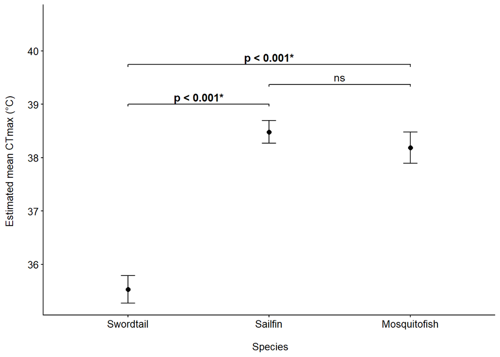

```r
#install.packages("scales")   #v1.4.0

### CTmax - EMM
O.df.pvals.max <- data.frame(
  group1 = c("Swordtail", "Sailfin", "Swordtail"),
  group2 = c("Sailfin", "Mosquitofish", "Mosquitofish"),
  label  = c("p < 0.001*", "ns", "p < 0.001*"),
  y.position = c(39, 39, 39))

O.df.pvals.max$fontface <- ifelse(O.df.pvals.max$label == "ns", "plain", "bold")

O.PW.df.max <- as.data.frame(confint(PW.sp.max))

O.emmean.max <- ggplot(O.PW.df.max, aes(x=Species, y=emmean)) +
  geom_point(size=2) +
  geom_errorbar(aes(ymin=lower.CL, ymax=upper.CL), width=0.1) +
  scale_y_continuous(breaks = scales::pretty_breaks(n = 6),
                     expand = expansion(mult = c(0.05, 0.25))) +
  stat_pvalue_manual(
    O.df.pvals.max,
    label = "label",
    tip.length = 0.01,
    bracket.size = 0.5,
    step.increase = 0.1,
    fontface = "fontface") +
  ylab("Estimated mean CTmax (\u00B0C) \n") +
  xlab("\n Species") +
  theme_classic(base_size = 10, base_family = "sans") +
  theme(
    axis.title.y = element_text(size = 10, family = "sans"),
    axis.text.y  = element_text(size = 10, family = "sans"),
    axis.text.x  = element_text(size = 10, family = "sans"),
    strip.text    = element_text(size = 10, family = "sans"))
O.emmean.max
```

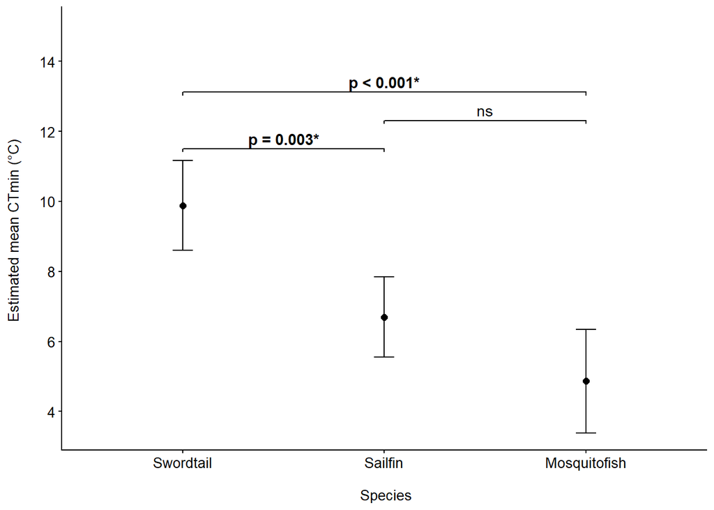

```r
### CTmin-EMM

O.df.pvals.min <- data.frame(
  group1 = c("Swordtail", "Sailfin", "Swordtail"),
  group2 = c("Sailfin", "Mosquitofish", "Mosquitofish"),
  label  = c("p = 0.003*", "ns", "p < 0.001*"),
  y.position = c(11.5, 11.5, 11.5))

O.df.pvals.min$fontface <- ifelse(O.df.pvals.min$label == "ns", "plain", "bold")

O.PW.df.min <- as.data.frame(confint(PW.sp.min))

O.emmean.min <- ggplot(O.PW.df.min, aes(x=Species, y=emmean)) +
  geom_point(size=2) +
  geom_errorbar(aes(ymin=lower.CL, ymax=upper.CL), width=0.1) +
  scale_y_continuous(breaks = scales::pretty_breaks(n = 6),
                     expand = expansion(mult = c(0.05, 0.25))) +
  ylab("Estimated mean CTmin (\u00B0C) \n") +
  stat_pvalue_manual(
    O.df.pvals.min,
    label = "label",
    tip.length = 0.01,
    bracket.size = 0.5,
    step.increase = 0.1,
    fontface = "fontface") +
  xlab("\n Species") +
  theme_classic(base_size = 10, base_family = "sans") +
  theme(
    axis.title.y = element_text(size = 10, family = "sans"),
    axis.text.y  = element_text(size = 10, family = "sans"),
    axis.text.x  = element_text(size = 10, family = "sans"),
    strip.text    = element_text(size = 10, family = "sans"))
O.emmean.min
```

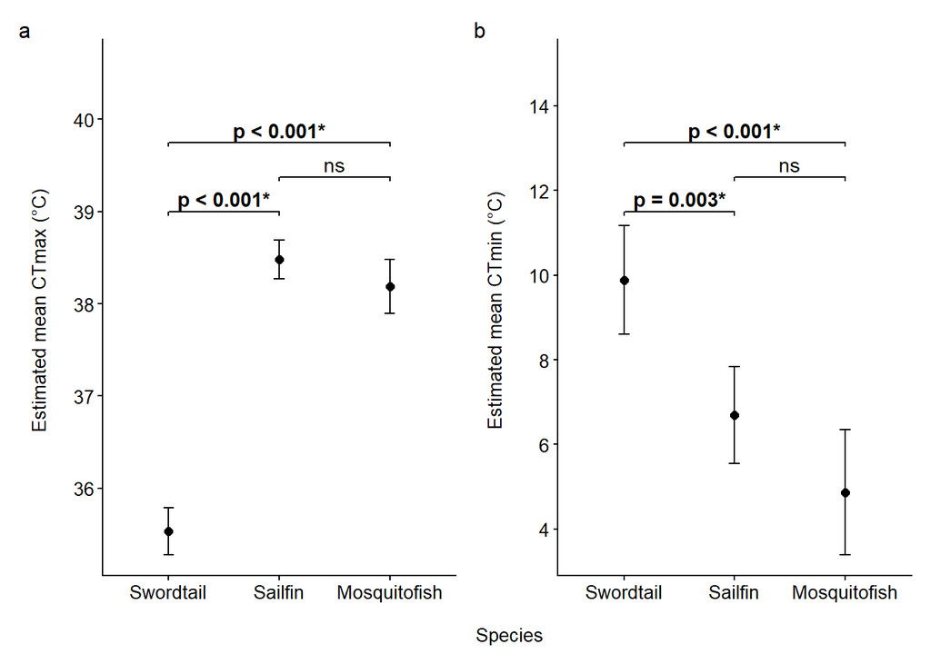

```r
O.final.plot_em.spp<- ((O.emmean.max + O.emmean.min) + plot_layout(axis_titles = "collect") + plot_annotation(tag_levels = "a"))
O.final.plot_em.spp
```

```r
#Save as tiff
ggsave(
  filename = "OnlineResource5_em-species.tiff",
  plot = O.final.plot_em.spp,
  device = ragg::agg_tiff,
  width = 6.85,
  height = 7,
  units = "in",
  dpi = 600)

#save as eps
ggsave(
  filename = "OnlineResource5_em-species.eps",
  plot = O.final.plot_em.spp,
  device = cairo_ps,
  width = 6.85,
  height = 7,
  units = "in",
  dpi = 600)
```

### Sex & size

```r
#install.packages("lme4")

### CTmax- sex and size

# Extract observations used in the full model
df.max <- model.frame(mod1d)

# Generate predictions only within each observed species x sex size range
pred.max <- df.max %>%
  group_by(Species, Sex) %>%
  reframe(
    Size.mm = seq(
      min(Size.mm),
      max(Size.mm),
      length.out = 50))

# Construct fixed-effect design matrix
X <- model.matrix(
  delete.response(
    terms(lme4::nobars(formula(mod1d)))),
  data = pred.max)
```

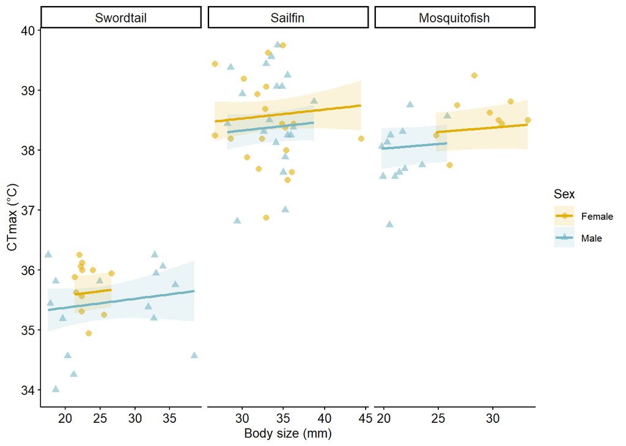

```r
# Model coefficients and covariance matrix
beta <- lme4::fixef(mod1d)
V <- as.matrix(vcov(mod1d))

X <- X[, names(beta), drop = FALSE]
V <- V[names(beta), names(beta), drop = FALSE]

# Predicted means and approximate 95% confidence intervals
pred.max$fit <- as.numeric(X %*% beta)

pred.max$SE <- sqrt(
  rowSums((X %*% V) * X))

pred.max$lower <- pred.max$fit - 1.96 * pred.max$SE
pred.max$upper <- pred.max$fit + 1.96 * pred.max$SE

# Plot
O.sex.size.plot.max <- ggplot(df.max, aes(x = Size.mm, y = CTmax.C, color = Sex)) +
  geom_point(aes(shape= Sex), alpha = 0.6, size = 2) +
  geom_ribbon(data = pred.max, aes(
      x = Size.mm,
      ymin = lower,
      ymax = upper,
      fill = Sex,
      group = Sex),
    inherit.aes = FALSE,
    alpha = 0.15) +
  geom_line(
    data = pred.max, aes(x = Size.mm, y = fit, color = Sex, group = Sex),
    inherit.aes = FALSE,
    linewidth = 1) +
  facet_wrap(~ Species, scales = "free_x") +
  scale_y_continuous(breaks = scales::pretty_breaks(n=5)) +
  labs(
    x = "Body size (mm)",
    y = "CTmax (°C)",
    color = "Sex",
    fill = "Sex") +
  scale_shape_manual(name = "Sex",
                     values = c("female" = 16, "male" = 17),
                     labels = c("female"="Female", "male"="Male")) +
  scale_color_manual(name="Sex",
                     values = c("female"="#E1AF00", "male"="#78B7C5"),
                     labels = c("female"="Female", "male"="Male")) +
  scale_fill_manual(name="Sex",
                     values = c("female"="#E1AF00", "male"="#78B7C5"),
                     labels = c("female"="Female", "male"="Male")) +
  theme_classic(base_size = 10, base_family = "sans") +
  theme(
    axis.title.y = element_text(size = 10, family = "sans"),
    axis.text.y  = element_text(size = 10, family = "sans"),
    axis.text.x  = element_text(size = 10, family = "sans"),
    strip.text    = element_text(size = 10, family = "sans"))

O.sex.size.plot.max
```

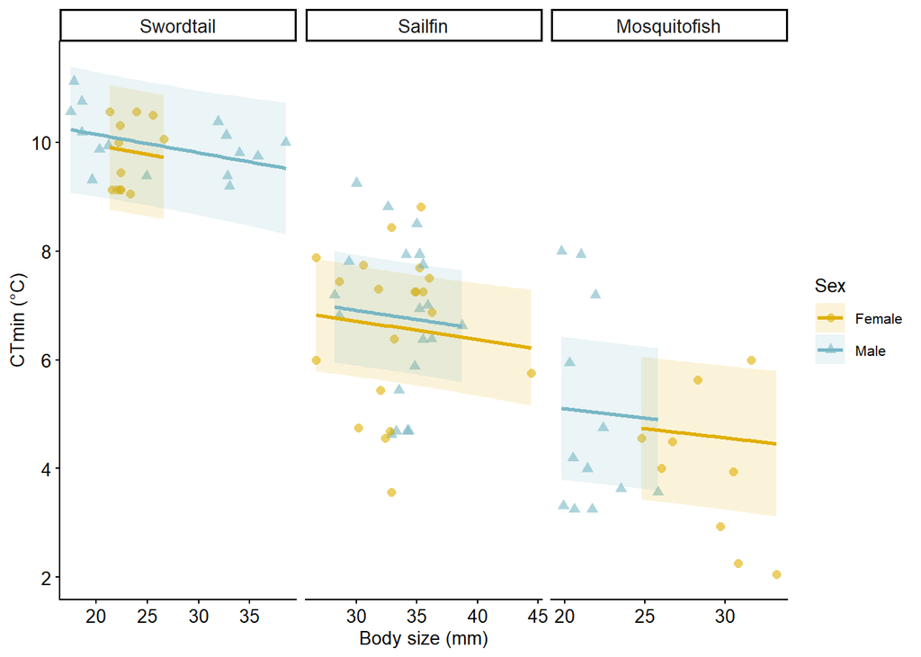

```r
### CTmin- sex and size
# Extract observations used in the full model
df.min <- model.frame(mod2d)

# Generate predictions only within each observed species x sex size range
pred.min <- df.min %>%
  group_by(Species, Sex) %>%
  reframe(
    Size.mm = seq(
      min(Size.mm),
      max(Size.mm),
      length.out = 50))

# Construct fixed-effect design matrix
X2 <- model.matrix(
  delete.response(
    terms(lme4::nobars(formula(mod2d)))),
  data = pred.min)

# Model coefficients and covariance matrix
beta2 <- lme4::fixef(mod2d)
V2 <- as.matrix(vcov(mod2d))

X2 <- X2[, names(beta2), drop = FALSE]
V2 <- V2[names(beta2), names(beta2), drop = FALSE]

# Predicted means and approximate 95% confidence intervals
pred.min$fit <- as.numeric(X2 %*% beta2)

pred.min$SE <- sqrt(
  rowSums((X2 %*% V2) * X2))

pred.min$lower <- pred.min$fit - 1.96 * pred.min$SE
pred.min$upper <- pred.min$fit + 1.96 * pred.min$SE

# Plot
O.sex.size.plot.min <- ggplot(df.min, aes(x = Size.mm, y = CTmin.C, color = Sex)) +
  geom_point(aes(shape= Sex), alpha = 0.6, size = 2) +
  geom_ribbon(data = pred.min, aes(
    x = Size.mm,
    ymin = lower,
    ymax = upper,
    fill = Sex,
    group = Sex),
    inherit.aes = FALSE,
    alpha = 0.15) +
  geom_line(
    data = pred.min, aes(x = Size.mm, y = fit, color = Sex, group = Sex),
    inherit.aes = FALSE,
    linewidth = 1) +
  facet_wrap(~ Species, scales = "free_x") +
  scale_y_continuous(breaks = scales::pretty_breaks(n=6)) +
  labs(
    x = "Body size (mm)",
    y = "CTmin (°C)",
    color = "Sex",
    fill = "Sex") +
  scale_shape_manual(name = "Sex",
                     values = c("female" = 16, "male" = 17),
                     labels = c("female"="Female", "male"="Male")) +
  scale_color_manual(name="Sex",
                     values = c("female"="#E1AF00", "male"="#78B7C5"),
                     labels = c("female"="Female", "male"="Male")) +
  scale_fill_manual(name="Sex",
                    values = c("female"="#E1AF00", "male"="#78B7C5"),
                    labels = c("female"="Female", "male"="Male")) +
  theme_classic(base_size = 10, base_family = "sans") +
  theme(
    axis.title.y = element_text(size = 10, family = "sans"),
    axis.text.y  = element_text(size = 10, family = "sans"),
    axis.text.x  = element_text(size = 10, family = "sans"),
    strip.text    = element_text(size = 10, family = "sans"))

O.sex.size.plot.min
```

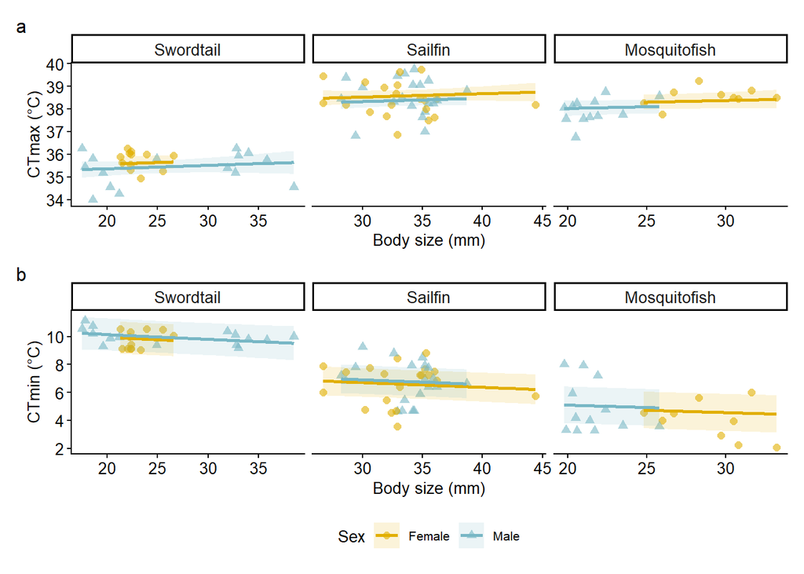

```r
### Combining

O.final.plot_sex.size<- ((O.sex.size.plot.max/O.sex.size.plot.min) + plot_layout(guides = "collect") + plot_annotation(tag_levels = "a") & theme(legend.position = "bottom"))
O.final.plot_sex.size
```

```r
#Save as tiff
ggsave(
  filename = "OnlineResource5_sex.size.tiff",
  plot = O.final.plot_sex.size,
  device = ragg::agg_tiff,
  width = 6.85,
  height = 7,
  units = "in",
  dpi = 600)

#save as eps
ggsave(
  filename = "OnlineResource5_sex.size.eps",
  plot = O.final.plot_sex.size,
  device = cairo_ps,
  width = 6.85,
  height = 7,
  units = "in",
  dpi = 600)
```

### Total temp range

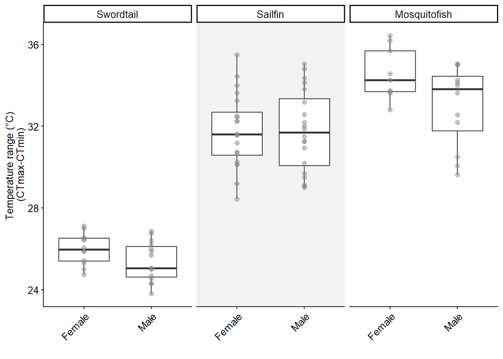

```r
O.dat.plot3 <- O.rawTempData %>%
  mutate(
    Sex.plot3 = case_when(
      Sex == "male" ~ "Male",
      Sex == "female" ~ "Female")) %>%
  mutate(T.tot = CTmax.C - CTmin.C)

O.range.plot <- ggplot(O.dat.plot3, aes(x = Sex.plot3, y = T.tot)) +
  geom_rect(
    data = subset(O.datTot, Species == "Sailfin"),
    inherit.aes = FALSE,
    xmin = -Inf, xmax = Inf,
    ymin = -Inf, ymax = Inf,
    fill = "grey95") +
  geom_boxplot() +
  geom_point(color= "#8D8680", size=2, alpha=0.5) +
  facet_wrap(~ Species, scales = "free_x") +
  theme_classic(base_size = 10, base_family = "sans") +
  theme(
    axis.title.y = element_text(size = 10, family = "sans"),
    axis.text.y  = element_text(size = 10, family = "sans"),
    axis.text.x  = element_text(size = 10, family = "sans"),
    strip.text    = element_text(size = 10, family = "sans")) +
  theme(axis.text.x = element_text(angle = 45, hjust = 1)) +
  xlab("") +
  ylab("Temperature range (\u00B0C) \n(CTmax-CTmin)")
O.range.plot
```

```r
#Save as tiff
ggsave(
  filename = "OnlineResource4_species-range.tiff",
  plot = O.range.plot,
  device = ragg::agg_tiff,
  width = 3.3,
  height = 4,
  units = "in",
  dpi = 600)


#Save as eps
ggsave(
  filename = "OnlineResource5_species-range.eps",
  plot = O.range.plot,
  device = cairo_ps,
  width = 3.3,
  height = 4,
  units = "in",
  dpi = 600)
```

### Swordtail emmeans

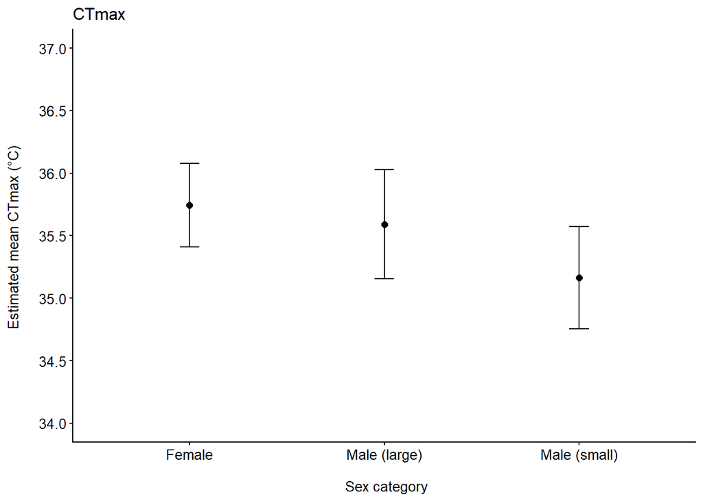

```r
### CTmax-EMM
O.PW.df.maxSW <- as.data.frame(confint(PW.sw.max))

O.SW.em.max <- ggplot(O.PW.df.maxSW, aes(x=Sex.plot, y=emmean)) +
  geom_point(size=2) +
  geom_errorbar(aes(ymin=lower.CL, ymax=upper.CL), width=0.1) +
  scale_y_continuous(breaks = scales::pretty_breaks(n=6)) +
  coord_cartesian(ylim = c(34, 37)) +
  ylab("Estimated mean CTmax (\u00B0C) \n") +
  xlab("\n Sex category") +
  ggtitle("CTmax") +
  theme_classic(base_size = 10, base_family = "sans") +
  theme(
    axis.title.y = element_text(size = 10, family = "sans"),
    axis.text.y  = element_text(size = 10, family = "sans"),
    axis.text.x  = element_text(size = 10, family = "sans"),
    strip.text    = element_text(size = 10, family = "sans"))
O.SW.em.max
```

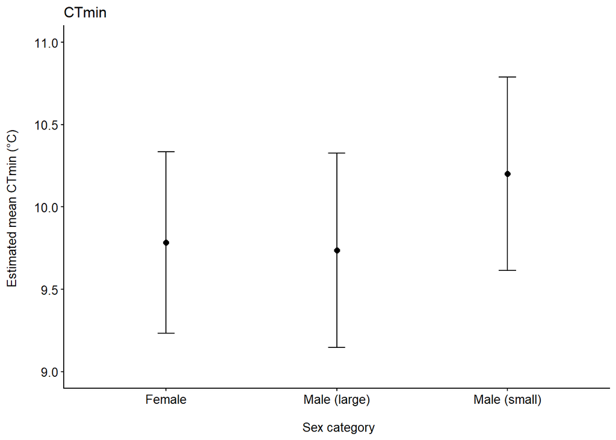

```r
### CTmin-EMM
O.PW.df.minSW <- as.data.frame(confint(PW.sw.min))

O.SW.em.min <- ggplot(O.PW.df.minSW, aes(x=Sex.plot, y=emmean)) +
  geom_point(size=2) +
  geom_errorbar(aes(ymin=lower.CL, ymax=upper.CL), width=0.1) +
  scale_y_continuous(breaks = scales::pretty_breaks(n = 6)) +
  coord_cartesian(ylim = c(9, 11)) +
  ylab("Estimated mean CTmin (\u00B0C) \n") +
  xlab("\n Sex category") +
  ggtitle("CTmin") +
  theme_classic(base_size = 10, base_family = "sans") +
  theme(
    axis.title.y = element_text(size = 10, family = "sans"),
    axis.text.y  = element_text(size = 10, family = "sans"),
    axis.text.x  = element_text(size = 10, family = "sans"),
    strip.text    = element_text(size = 10, family = "sans"))
O.SW.em.min
```

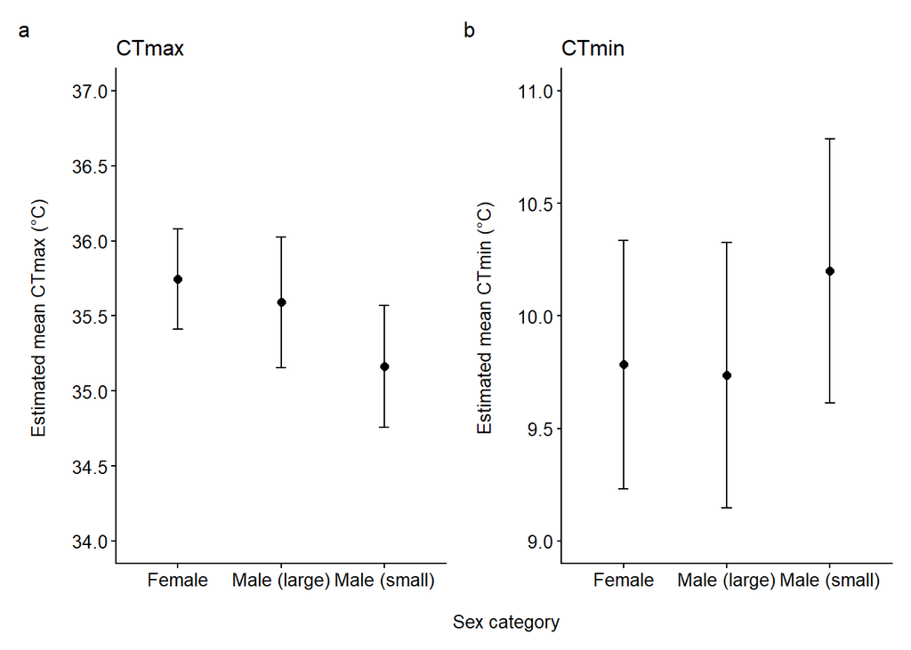

```r
### Combining

O.final.plot_em.sw <- ((O.SW.em.max + O.SW.em.min) + plot_layout(axis_titles = "collect") + plot_annotation(tag_levels = "a"))
O.final.plot_em.sw
```

```r
#Save as tiff
ggsave(
  filename = "OnlineResource5_em-sw.tiff",
  plot = O.final.plot_em.sw,
  device = ragg::agg_tiff,
  width = 6.85,
  height = 7,
  units = "in",
  dpi = 600)


#Save as eps
ggsave(
  filename = "OnlineResource5_em-sw.eps",
  plot = O.final.plot_em.sw,
  device = cairo_ps,
  width = 6.85,
  height = 7,
  units = "in",
  dpi = 600)
```

### Model diagnostics

```r
# ----------------------------------------------------------------------------------
### CTmax & CTmin model selection ###
# ----------------------------------------------------------------------------------
max.sel <- model.sel(mod1, mod1b, mod1c, mod1d, mod1e, mod1f, mod1g)
min.sel <- model.sel(mod2, mod2b, mod2c, mod2d, mod2e, mod2f, mod2g)

prepare.sel <- function(sel, trait) {
  as.data.frame(sel) %>%
    tibble::rownames_to_column("Model") %>%
    mutate(Trait = trait) %>%
    select(Trait, Model, df, AICc, delta, weight)}

sel.all <- bind_rows(
  prepare.sel(min.sel, "CTmin"),
  prepare.sel(max.sel, "CTmax")) %>%
  mutate(Trait = factor(Trait, levels = c("CTmin", "CTmax"))) %>%
  mutate(Model = dplyr::recode(
    as.character(Model),
    mod1 = "Species",
    mod1b = "Species + Size",
    mod1c = "Species + Sex",
    mod1d = "Species + Size \n+Sex",
    mod1e = "Species + \nSize * Sex",
    mod1f = "Species * Sex \n+ Size",
    mod1g = "Species * Size \n+ Sex",
    mod2 = "Species",
    mod2b = "Species + Size",
    mod2c = "Species + Sex",
    mod2d = "Species + Size \n+Sex",
    mod2e = "Species + \nSize * Sex",
    mod2f = "Species * Sex \n+ Size",
    mod2g = "Species * Size \n+ Sex"))

O.model.table <- sel.all %>%
  gt(rowname_col = "Model", groupname_col = "Trait", row_group_as_column = TRUE) %>%
  #tab_stubhead(label = "Model") %>%
  cols_label(
    Model = "Model",
    df = "df",
    AICc = "AICc",
    delta = "ΔAICc",
    weight = "Weight") %>%
  fmt_number(columns = c(AICc, delta), decimals = 2) %>%
  fmt_number(columns = weight, decimals = 3) %>%
  tab_style(
    style = cell_borders(sides = "right", color = "lightgray", weight = px(1.5)),
    locations = cells_body(columns = c(df, AICc, delta)))

O.model.table
```

|  |  | df | AICc | ΔAICc | Weight |
| --- | --- | --- | --- | --- | --- |
| CTmin | Species + Size +Sex | 7 | 204.08 | 0.00 | 0.329 |
|  | Species + Size | 6 | 204.32 | 0.23 | 0.293 |
|  | Species + Sex | 6 | 206.21 | 2.13 | 0.114 |
|  | Species + Size * Sex | 8 | 206.51 | 2.42 | 0.098 |
|  | Species | 5 | 206.82 | 2.73 | 0.084 |
|  | Species * Size + Sex | 9 | 208.03 | 3.95 | 0.046 |
|  | Species * Sex + Size | 9 | 208.44 | 4.36 | 0.037 |
| CTmax | Species + Size * Sex | 8 | 190.14 | 0.00 | 0.303 |
|  | Species | 5 | 190.96 | 0.82 | 0.201 |
|  | Species + Sex | 6 | 191.17 | 1.03 | 0.181 |
|  | Species + Size | 6 | 192.25 | 2.11 | 0.105 |
|  | Species + Size +Sex | 7 | 192.64 | 2.50 | 0.087 |
|  | Species * Sex + Size | 9 | 193.05 | 2.92 | 0.071 |
|  | Species * Size + Sex | 9 | 193.69 | 3.55 | 0.051 |

```r
gtsave(O.model.table, "OnlineResource4_model-sel.rtf")


# ----------------------------------------------------------------------------------
### CTmax & CTmin main model diagnostics ###
# ----------------------------------------------------------------------------------

# Simulate residuals once
sim.max <- simulateResiduals(mod1, n = 1000)
sim.min <- simulateResiduals(mod2, n = 1000)

build_diagnostic_plot <- function() {

  oldpar <- par(no.readonly = TRUE)
  on.exit(par(oldpar))

  # Three rows, two columns
  par(
    mfrow = c(3, 2),
    mar = c(4, 4, 3.5, 1),
    cex = 0.75,
    family = "sans")

  # A: CTmax QQ
  plotQQunif(
    sim.max,
    main = "A. CTmax: species-only model checks")

  # B: CTmin QQ
  plotQQunif(
    sim.min,
    main = "B. CTmin: species-only model checks")

  # C: CTmax residuals vs predicted
  plotResiduals(sim.max)

  # D: CTmin residuals vs predicted
  plotResiduals(sim.min)

  # E: CTmax residuals vs species
  plotResiduals(sim.max, form = as.factor(model.frame(mod1)$Species))

  # F: CTmin residuals vs species
  plotResiduals(sim.min, form = as.factor(model.frame(mod2)$Species))
}

# TIFF
tiff(
  "OnlineResource5_mainResidChecks.tiff",
  width = 6.85,
  height = 7,
  units = "in",
  res = 600,
  compression = "lzw",
  type = "cairo")
build_diagnostic_plot()
dev.off()
```

```r
# EPS

cairo_ps(
  "OnlineResource5_mainResidChecks.eps",
  width = 6.85,
  height = 7,
  onefile = FALSE,
  fallback_resolution = 600)
build_diagnostic_plot()
dev.off()
```

```r
# ----------------------------------------------------------------------------------
### CTmax & CTmin alt model diagnostics ###
# ----------------------------------------------------------------------------------

# Simulate residuals
sim.size.max <- simulateResiduals(mod1b, n = 1000)
sim.sex.max <- simulateResiduals(mod1c, n = 1000)
sim.sss.max <- simulateResiduals(mod1d, n = 1000)
sim.size.min <- simulateResiduals(mod2b, n = 1000)
sim.sex.min <- simulateResiduals(mod2c, n = 1000)
sim.sss.min <- simulateResiduals(mod2d, n = 1000)

# ----------------------------
#### SPECIES + SIZE MODEL ####
# ----------------------------

build_SIZEdiagnostic_plot <- function() {

  oldpar <- par(no.readonly = TRUE)
  on.exit(par(oldpar))

  # Four rows, two columns
  par(
    mfrow = c(4, 2),
    mar = c(4, 4, 3.5, 1),
    cex = 0.75,
    family = "sans")

  # A: CTmax QQ
  plotQQunif(
    sim.size.max,
    main = "A. CTmax: species+size model checks")

  # B: CTmin QQ
  plotQQunif(
    sim.size.min,
    main = "B. CTmin: species+size model checks")

  # C: CTmax residuals vs predicted
  plotResiduals(sim.size.max)

  # D: CTmin residuals vs predicted
  plotResiduals(sim.size.min)

  # E: CTmax residuals vs species
  plotResiduals(sim.size.max, form = as.factor(model.frame(mod1b)$Species))

  # F: CTmin residuals vs species
  plotResiduals(sim.size.min, form = as.factor(model.frame(mod2b)$Species))

  # G: CTmax residuals vs size
  plotResiduals(sim.size.max, form = model.frame(mod1b)$Size.mm)

  # H: CTmin residuals vs size
  plotResiduals(sim.size.min, form = model.frame(mod2b)$Size.mm)
}

# TIFF
tiff(
  "OnlineResource5_SizemodResidChecks.tiff",
  width = 6.85,
  height = 7,
  units = "in",
  res = 600,
  compression = "lzw",
  type = "cairo")
build_SIZEdiagnostic_plot()
dev.off()
```

```r
# EPS

cairo_ps(
  "OnlineResource5_SizemodResidChecks.eps",
  width = 6.85,
  height = 7,
  onefile = FALSE,
  fallback_resolution = 600)
build_SIZEdiagnostic_plot()
dev.off()
```

```r
# ---------------------------
#### SPECIES + SEX MODEL ####
# ---------------------------

build_SEXdiagnostic_plot <- function() {

  oldpar <- par(no.readonly = TRUE)
  on.exit(par(oldpar))

  # Four rows, two columns
  par(
    mfrow = c(4, 2),
    mar = c(4, 4, 3.5, 1),
    cex = 0.75,
    family = "sans")

  # A: CTmax QQ
  plotQQunif(
    sim.sex.max,
    main = "A. CTmax: species+sex model checks")

  # B: CTmin QQ
  plotQQunif(
    sim.sex.min,
    main = "B. CTmin: species+sex model checks")

  # C: CTmax residuals vs predicted
  plotResiduals(sim.sex.max)

  # D: CTmin residuals vs predicted
  plotResiduals(sim.sex.min)

  # E: CTmax residuals vs species
  plotResiduals(sim.sex.max, form = as.factor(model.frame(mod1c)$Species))

  # F: CTmin residuals vs species
  plotResiduals(sim.sex.min, form = as.factor(model.frame(mod2c)$Species))

  # G: CTmax residuals vs sex
  plotResiduals(sim.sex.max, form = as.factor(model.frame(mod1c)$Sex))

  # H: CTmin residuals vs sex
  plotResiduals(sim.sex.min, form = as.factor(model.frame(mod2c)$Sex))
}

# TIFF
tiff(
  "OnlineResource5_SexmodResidChecks.tiff",
  width = 6.85,
  height = 7,
  units = "in",
  res = 600,
  compression = "lzw",
  type = "cairo")
build_SEXdiagnostic_plot()
dev.off()
```

```r
# EPS

cairo_ps(
  "OnlineResource5_SexmodResidChecks.eps",
  width = 6.85,
  height = 7,
  onefile = FALSE,
  fallback_resolution = 600)
build_SEXdiagnostic_plot()
dev.off()
```

```r
# -----------------------------------
#### SPECIES + SIZE + SEX MODELS ####
# -----------------------------------

build_SSSdiagnostic_plot <- function() {

  oldpar <- par(no.readonly = TRUE)
  on.exit(par(oldpar))

  # Five rows, two columns
  par(
    mfrow = c(5, 2),
    mar = c(4, 4, 3.5, 1),
    cex = 0.75,
    family = "sans")

  # A: CTmax QQ
  plotQQunif(
    sim.sss.max,
    main = "A. CTmax: species+size+sex model checks")

  # B: CTmin QQ
  plotQQunif(
    sim.sss.min,
    main = "B. CTmin: species+size+sex model checks")

  # C: CTmax residuals vs predicted
  plotResiduals(sim.sss.max)

  # D: CTmin residuals vs predicted
  plotResiduals(sim.sss.min)

  # E: CTmax residuals vs species
  plotResiduals(sim.sss.max, form = as.factor(model.frame(mod1d)$Species))

  # F: CTmin residuals vs species
  plotResiduals(sim.sss.min, form = as.factor(model.frame(mod2d)$Species))

  # G: CTmax residuals vs size
  plotResiduals(sim.sss.max, form = model.frame(mod1d)$Size.mm)

  # H: CTmin residuals vs size
  plotResiduals(sim.sss.min, form = model.frame(mod2d)$Size.mm)

  # I: CTmax residuals vs sex
  plotResiduals(sim.sss.max, form = as.factor(model.frame(mod1d)$Sex))

  # J: CTmin residuals vs sex
  plotResiduals(sim.sss.min, form = as.factor(model.frame(mod2d)$Sex))
}

# TIFF
tiff(
  "OnlineResource5_CombomodResidChecks.tiff",
  width = 6.85,
  height = 7,
  units = "in",
  res = 600,
  compression = "lzw",
  type = "cairo")
build_SSSdiagnostic_plot()
```

```
## qu = 0.5, log(sigma) = -2.882676 : outer Newton did not converge fully.
```

```r
dev.off()
```

```r
# EPS

cairo_ps(
  "OnlineResource5_CombomodResidChecks.eps",
  width = 6.85,
  height = 7,
  onefile = FALSE,
  fallback_resolution = 600)
build_SSSdiagnostic_plot()
```

```
## qu = 0.5, log(sigma) = -2.882676 : outer Newton did not converge fully.
```

```r
dev.off()
```

```r
# ----------------------------------------------------------------------------------
### CTmax & CTmin swordtail model selection ###
# ----------------------------------------------------------------------------------
SW.max.sel <- model.sel(SWmod1, SWmod2, SWmod3)
SW.min.sel <- model.sel(SWmod4, SWmod5, SWmod6)

sel.sw <- bind_rows(
  prepare.sel(SW.min.sel, "CTmin"),
  prepare.sel(SW.max.sel, "CTmax")) %>%
  mutate(Trait = factor(Trait, levels = c("CTmin", "CTmax"))) %>%
  mutate(Model = dplyr::recode(
    as.character(Model),
    SWmod1 = "Sex category",
    SWmod2 = "Sex category + Size",
    SWmod3 = "Sex category * Size",
    SWmod4 = "Sex category",
    SWmod5 = "Sex category + Size",
    SWmod6 = "Sex category * Size"))

O.SW.model.table <- sel.sw %>%
  gt(rowname_col = "Model", groupname_col = "Trait", row_group_as_column = TRUE) %>%
  #tab_stubhead(label = "Model") %>%
  cols_label(
    Model = "Model",
    df = "df",
    AICc = "AICc",
    delta = "ΔAICc",
    weight = "Weight") %>%
  fmt_number(columns = c(AICc, delta), decimals = 2) %>%
  fmt_number(columns = weight, decimals = 3) %>%
  tab_style(
    style = cell_borders(sides = "right", color = "lightgray", weight = px(1.5)),
    locations = cells_body(columns = c(df, AICc, delta)))

O.SW.model.table
```

|  |  | df | AICc | ΔAICc | Weight |
| --- | --- | --- | --- | --- | --- |
| CTmin | Sex category | 5 | 47.20 | 0.00 | 0.832 |
|  | Sex category + Size | 6 | 50.45 | 3.25 | 0.164 |
|  | Sex category * Size | 8 | 57.77 | 10.57 | 0.004 |
| CTmax | Sex category | 5 | 58.37 | 0.00 | 0.721 |
|  | Sex category + Size | 6 | 60.34 | 1.96 | 0.270 |
|  | Sex category * Size | 8 | 67.16 | 8.78 | 0.009 |

```r
gtsave(O.SW.model.table, "OnlineResource4_SWmodel-sel.rtf")

# ----------------------------------------------------------------------------------
### Swordtail model diagnostics ###
# ----------------------------------------------------------------------------------


# Simulate residuals once
SW.sim.max <- simulateResiduals(SWmod1, n = 1000)
SW.sim.min <- simulateResiduals(SWmod4, n = 1000)

build_SWdiagnostic_plot <- function() {

  oldpar <- par(no.readonly = TRUE)
  on.exit(par(oldpar))

  # Three rows, two columns
  par(
    mfrow = c(3, 2),
    mar = c(4, 4, 3.5, 1),
    cex = 0.75,
    family = "sans")

  # A: CTmax QQ
  plotQQunif(
    SW.sim.max,
    main = "A. CTmax: sex category model checks")

  # B: CTmin QQ
  plotQQunif(
    SW.sim.min,
    main = "B. CTmin: sex category model checks")

  # C: CTmax residuals vs predicted
  plotResiduals(SW.sim.max)

  # D: CTmin residuals vs predicted
  plotResiduals(SW.sim.min)

  # E: CTmax residuals vs species
  plotResiduals(SW.sim.max, form = as.factor(model.frame(SWmod1)$Sex.plot))

  # F: CTmin residuals vs species
  plotResiduals(SW.sim.min, form = as.factor(model.frame(SWmod2)$Sex.plot))
}

# TIFF
tiff(
  "OnlineResource5_SWResidChecks.tiff",
  width = 6.85,
  height = 7,
  units = "in",
  res = 600,
  compression = "lzw",
  type = "cairo")
build_SWdiagnostic_plot()
dev.off()
```

```r
# EPS

cairo_ps(
  "OnlineResource5_SWResidChecks.eps",
  width = 6.85,
  height = 7,
  onefile = FALSE,
  fallback_resolution = 600)
build_SWdiagnostic_plot()
dev.off()
```